# RepData_Week2 Assignment Peer-graded Assignment: Course Project 1

Daisy Niu

10/20/2019

## Load library needed for data analysis/plotting

```r
library(ggplot2)
library(dplyr)
```

## Set working directory and Download/unzip data to the working directory.

```r
setwd("C:/OnlineCourse/DataScience/ReproductibleResearch/Week2_Project")

download.file("https://d396qusza40orc.cloudfront.net/repdata%2Fdata%2Factivity.zip","repdata_data_activity.zip")

unzip("repdata_data_activity.zip")
```

## Read data and pre-process data for analysis

```r
Activity<-read.csv("activity.csv")
head(Activity)
```

```
##   steps       date interval
## 1    NA 2012-10-01        0
## 2    NA 2012-10-01        5
## 3    NA 2012-10-01       10
## 4    NA 2012-10-01       15
## 5    NA 2012-10-01       20
## 6    NA 2012-10-01       25
```

## What is mean total number of steps taken per day?

### 1. Calculate the total number of steps taken per day

```r
Step_Date<-aggregate(steps~date, Activity, sum, na.rm=TRUE)
head(Step_Date)
```

```
##         date steps
## 1 2012-10-02   126
## 2 2012-10-03 11352
## 3 2012-10-04 12116
## 4 2012-10-05 13294
## 5 2012-10-06 15420
## 6 2012-10-07 11015
```

### 2. Histogram of the total number of steps taken per day

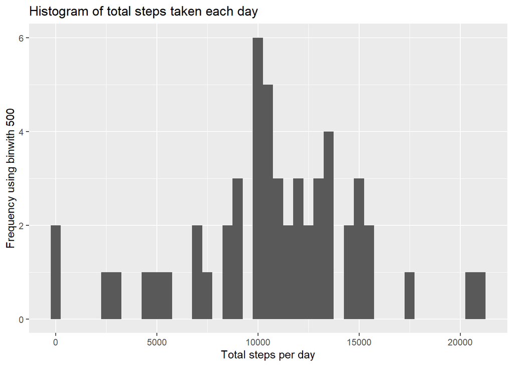

```r
qplot(steps,data=Step_Date,xlab='Total steps per day', ylab='Frequency using binwith 500',main='Histogram of total steps taken each day', binwidth=500)
```

### 3. Calculate mean and median of the total number of steps taken per day

```r
mean(Step_Date$steps)
```

```
## [1] 10766.19
```

```r
median(Step_Date$steps)
```

```
## [1] 10765
```

## What is the average daily activity pattern?

### 1. Make a time series plot

```r
Step_interval<-aggregate(steps~interval, Activity, mean, na.rm=TRUE)
head(Step_interval)
```

```
##   interval     steps
## 1        0 1.7169811
## 2        5 0.3396226
## 3       10 0.1320755
## 4       15 0.1509434
## 5       20 0.0754717
## 6       25 2.0943396
```

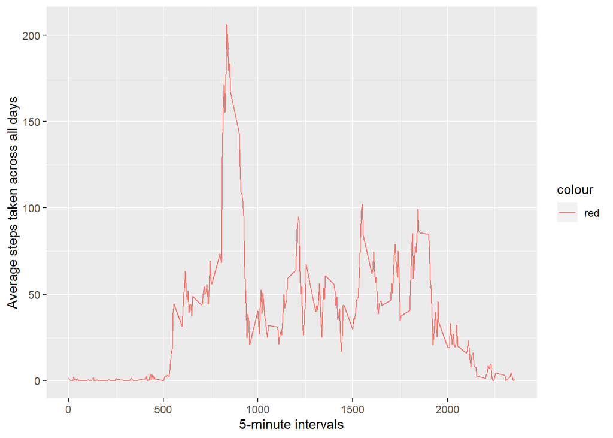

```r
qplot(interval,steps, data=Step_interval,geom='line', xlab = '5-minute intervals',ylab = 'Average steps taken across all days',color="red")
```

### 2. Which 5-minute interval, on average across all the days in the dataset, contains the maximum number of steps?

```r
Step_interval[which.max(Step_interval$steps),]
```

```
##     interval    steps
## 104      835 206.1698
```

## Imputing missing values

### 1. Calculate and report the total number of missing values in the dataset

```r
NA_Activity<-Activity[which(is.na(Activity$steps)),]
head(NA_Activity)
```

```
##   steps       date interval
## 1    NA 2012-10-01        0
## 2    NA 2012-10-01        5
## 3    NA 2012-10-01       10
## 4    NA 2012-10-01       15
## 5    NA 2012-10-01       20
## 6    NA 2012-10-01       25
```

```r
nrow(NA_Activity)
```

```
## [1] 2304
```

### 2-3. Create a new dataset that is equal to the original dataset but with the missing data filled in. Strategy: Replace NA with the mean steps of each interval.

```r
ActivityImputed<-Activity
ActivityImputed<-Activity %>% group_by(interval) %>% mutate(steps=replace(steps,is.na(steps), mean(steps,na.rm=TRUE)))
head(ActivityImputed)
```

```
## # A tibble: 6 x 3
## # Groups:   interval [6]
##    steps date       interval
##    <dbl> <fct>         <int>
## 1 1.72   2012-10-01        0
## 2 0.340  2012-10-01        5
## 3 0.132  2012-10-01       10
## 4 0.151  2012-10-01       15
## 5 0.0755 2012-10-01       20
## 6 2.09   2012-10-01       25
```

### 4. Make a histogram of the total number of steps taken each day and Calculate and report the mean and median total number of steps taken per day.

```r
Step_Date_Imputed<-aggregate(steps~date, ActivityImputed, sum, na.rm=TRUE)
head(Step_Date_Imputed)
```

```
##         date    steps
## 1 2012-10-01 10766.19
## 2 2012-10-02   126.00
## 3 2012-10-03 11352.00
## 4 2012-10-04 12116.00
## 5 2012-10-05 13294.00
## 6 2012-10-06 15420.00
```

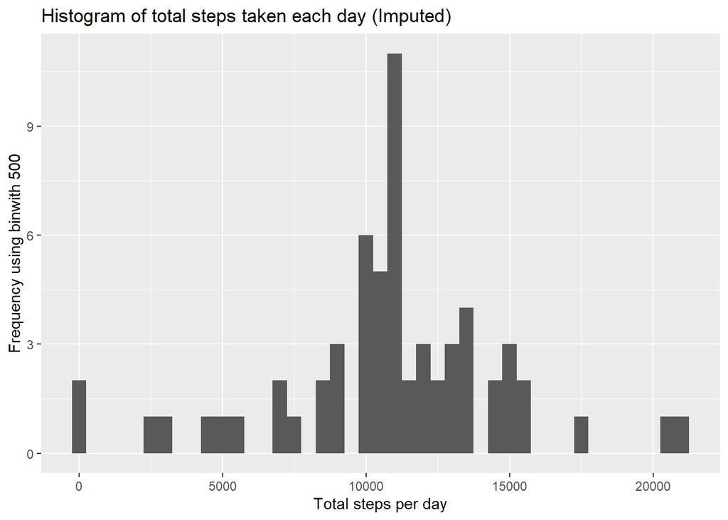

```r
qplot(steps,data=Step_Date_Imputed,xlab='Total steps per day', ylab='Frequency using binwith 500',main='Histogram of total steps taken each day (Imputed)', binwidth=500)
```

The total numbers of steps for each day with imputed data are larger because all NAs are filled with the mean of the interval.

Calculate and report the mean and the median.

```r
mean(Step_Date_Imputed$steps)
```

```
## [1] 10766.19
```

```r
median(Step_Date_Imputed$steps)
```

```
## [1] 10766.19
```

```r
summary(Step_Date_Imputed)
```

```
##          date        steps
##  2012-10-01: 1   Min.   :   41
##  2012-10-02: 1   1st Qu.: 9819
##  2012-10-03: 1   Median :10766
##  2012-10-04: 1   Mean   :10766
##  2012-10-05: 1   3rd Qu.:12811
##  2012-10-06: 1   Max.   :21194
##  (Other)   :55
```

## Are there differences in activity patterns between weekdays and weekends?

### 1.Create a new factor variable in the dataset with two levels – “weekday” and “weekend”

```r
ActivityImputed$DayWeek<-weekdays(as.Date(ActivityImputed$date))
ActivityImputed$weekend<-ifelse(ActivityImputed$DayWeek %in% c('Saturday', 'Sunday'),'weekend', 'weekday')
head(ActivityImputed)
```

```
## # A tibble: 6 x 5
## # Groups:   interval [6]
##    steps date       interval DayWeek weekend
##    <dbl> <fct>         <int> <chr>   <chr>
## 1 1.72   2012-10-01        0 Monday  weekday
## 2 0.340  2012-10-01        5 Monday  weekday
## 3 0.132  2012-10-01       10 Monday  weekday
## 4 0.151  2012-10-01       15 Monday  weekday
## 5 0.0755 2012-10-01       20 Monday  weekday
## 6 2.09   2012-10-01       25 Monday  weekday
```

### 2. Make a panel plot containing a time series plot of the 5-minute interval (x-axis) and the average number of steps taken, averaged across all weekday days or weekend days (y-axis).

```r
Step_interval_Imputed<-aggregate(ActivityImputed$steps, by=list(ActivityImputed$weekend,ActivityImputed$interval), FUN= "mean")
names(Step_interval_Imputed)<-c("weekend","interval","steps")
head(Step_interval_Imputed)
```

```
##   weekend interval      steps
## 1 weekday        0 2.25115304
## 2 weekend        0 0.21462264
## 3 weekday        5 0.44528302
## 4 weekend        5 0.04245283
## 5 weekday       10 0.17316562
## 6 weekend       10 0.01650943
```

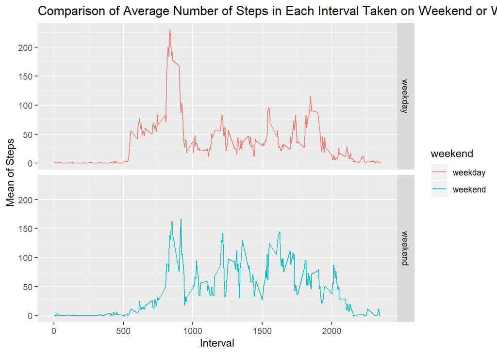

```r
ggplot(Step_interval_Imputed, aes(x=interval, y=steps, color=weekend)) + geom_line()+
facet_grid(weekend ~.) + xlab("Interval") + ylab("Mean of Steps") +
    ggtitle("Comparison of Average Number of Steps in Each Interval Taken on Weekend or Weekday")
```